# individual1

Nathan Marquardt

4/13/2021

1.Are there some days of the week where more accidents happen than the others (see FARS manual, use variable `DAY_WEEK`)?

Answer:

```r
library(dplyr)
library(tidyverse)
library(lubridate)
```

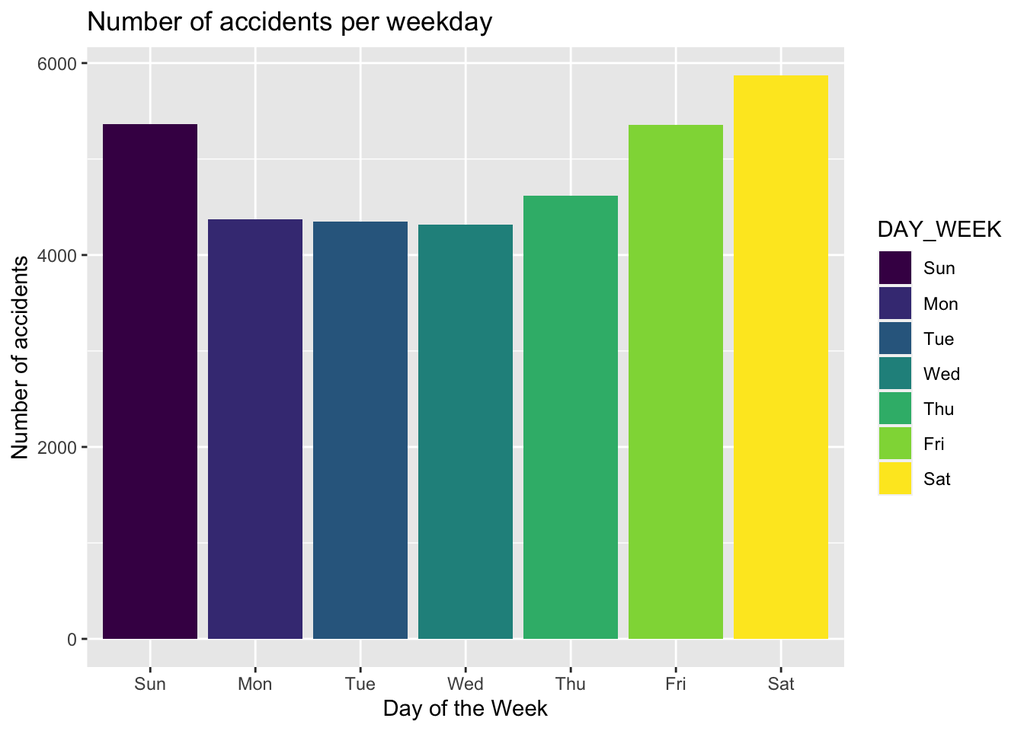

```r
library(classdata)

acc <- read.csv("https://raw.githubusercontent.com/xdaiISU/ds202materials/master/hwlabs/fars2017/accident.csv", stringsAsFactors = FALSE)
per <- read.csv("https://raw.githubusercontent.com/xdaiISU/ds202materials/master/hwlabs/fars2017/person.csv", stringsAsFactors = FALSE)

acc$DAY_WEEK <- wday(acc$DAY_WEEK, label = TRUE)

accCount <- acc %>%
            group_by(DAY_WEEK) %>%
            summarise(count = n())

ggplot(aes(x = DAY_WEEK, weight = count, fill = DAY_WEEK), data = accCount) + geom_bar() + xlab("Day of the Week") + ylab("Number of accidents") + ggtitle("Number of accidents per weekday")
```

According the barchart above, we can not that there seems to be an increase in accidents during the weekend (Thursday - Sunday)

2.Create a data frame containing the persons who are fatally hurt in the accidents (look up variable `INJ_SEV`).

Answer:

```r
perSev <- per %>%
          filter(INJ_SEV == 4)
```

3.Create a data frame containing the most dangerous vehicle make in each state. The number of persons fatally hit in the vehicle make is used to assess the (non-)safety of a make. Make sure to handle the missing values appropriately. (look up variable `MAKE`)

Answer:

```r
perMDV <- perSev %>%
          select(STATE, MAKE, INJ_SEV) %>%
          na.omit() %>%
          group_by(STATE, MAKE) %>%
          summarise(count = n())
?top_n

perMDVRes <- perMDV %>%
              group_by(STATE) %>%
              top_n(1, count)
```

4.Create a map, and label each state with the most dangerous vehicle. Discuss the definition of the *most dangerous vechicle*, and what you find from the map. (Hint: Read the description for the `STATE` and `COUNTY` columns in the FARS manual. The state and &county codes are Geographic Locator Codes (GLCs) from the General Services Administration’s (GSA) publication. Use `readxl::read_xlsx` to read in the GLCs.)

Answer:

5.Join the accident and person table (work out which varaible(s) to use)

Answer:

```r
accper <- full_join(acc, per, by="ST_CASE")
```

6.Tally the number of accidents by day of the week (Day_WEEK), hour of the day (HOUR) and gender (SEX). Visualize the results and explain what you find.

Answer:

7.Now plot a choropleth map of the number of deaths on a county level. Also explain what you find.

Answer:

8. Is summer or winter more dangerous? Does this depend on states? Explore and explain.

Answer:

```r
accWin <- acc %>%
          filter(MONTH == 12 | MONTH == 1 | MONTH == 2)

accSum <- acc %>%
          filter(MONTH == 6 | MONTH == 7 | MONTH == 8 | MONTH == 9)

length(accWin$ST_CASE)
```

```
## [1] 7733
```

```r
length(accSum$ST_CASE)
```

```
## [1] 12273
```

```r
perWin <- per %>%
                filter(MONTH == 12 | MONTH == 1 | MONTH == 2)

perSum <- per %>%
            filter(MONTH == 6 | MONTH == 7 | MONTH == 8 | MONTH == 9)

perWinFatal <- perWin %>%
                  filter(INJ_SEV == 4)

perSumFatal <- perSum %>%
                filter(INJ_SEV == 4)

percWinFatal <- length(perWinFatal$MONTH) / length(perWin$MONTH)
percSumFatal <- length(perSumFatal$MONTH) / length(perSum$MONTH)

perWinCount <- perWin %>%
                group_by(STATE, INJ_SEV) %>%
                summarise(win_Count = n())
perSumCount <- perSum %>%
                group_by(STATE, INJ_SEV) %>%
                summarise(sum_Count = n())
perInjCount <- full_join(perWinCount, perSumCount, by = c("STATE", "INJ_SEV"))

perWinStateCount <- perWin %>%
                      group_by(STATE) %>%
                      summarise(winST_count = n())

perSumStateCount <- perSum %>%
                    group_by(STATE) %>%
                    summarise(sumST_count = n())

perWinSumSTCount <- full_join(perWinStateCount, perSumStateCount, by = "STATE")

perInjCountPer <- full_join(perInjCount, perWinSumSTCount, by = "STATE")

perInj <- perInjCountPer %>%
          mutate(winPercentage = win_Count / winST_count, sumPercentage = sum_Count / sumST_count)
```